# Test Message Boxes

## Key Messages

Chemicals are often grouped based on how we’re exposed to them—through breathing, skin contact, or what we eat—and how we can avoid them, like washing hands, improving ventilation, or restricting certain products. Here are some key points from your results. Keep in mind that a chemical might show up in more than one group since chemicals can come from different sources.

You had Industrial & Commercial Chemicals compound, Indole detected at a high level that was not found in most other wristbands.

You had a higher level of Agricultural & Pharmaceutical Chemicals compound, Diethyl phthalate, compared to 95% of other people in the study.

You had Consumer & Personal Care Products compound, Indole detected at a high level that was not found in most other wristbands.

## Key Messages

Chemicals are often grouped based on how we’re exposed to them—through breathing, skin contact, or what we eat—and how we can avoid them, like washing hands, improving ventilation, or restricting certain products. Here are some key points from your results. Keep in mind that a chemical might show up in more than one group since chemicals can come from different sources.

You had Consumer & Personal Care Products compound, Indole detected at a high level that was not found in most other wristbands.

WHAT YOU CAN DO

Use natural alternatives, check labels, and reduce exposure.

You had Industrial & Commercial Chemicals compound, Indole detected at a high level that was not found in most other wristbands.

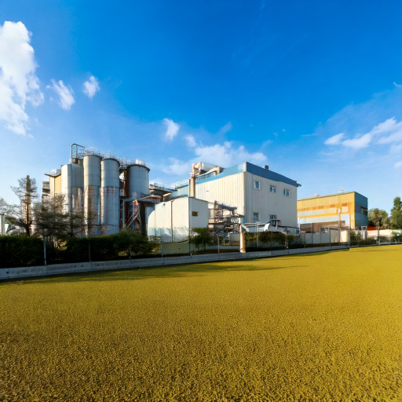

WHAT YOU CAN DO

Improve ventilation, use protective equipment, and follow safety protocols.

You had a higher level of Agricultural & Pharmaceutical Chemicals compound, Diethyl phthalate, compared to 95% of other people in the study.

[figure not shown]

WHAT YOU CAN DO

Wash produce, opt for organic options, and limit exposure.